# US House Election Forecasting

2022-10-29

## Load Packages and Data

```r
library(tidyverse)
library(fpp2)
library(dplyr)
library(gridExtra)
#Load Files
elec <- read.csv("US House Election Results 2.csv")
cs <- read.csv("Average Consumer Sentiment every 2 years.csv")
ar <- read.csv("Approval Ratings.csv")

#Converting into Timeseries
elec_ts <- ts(elec, start = 1978, deltat = 2)
cs_ts <- ts(cs, start = 1980, deltat = 2)
ar <- ar[,4]
ar_ts <- window(ts(ar, start = 1970, deltat = 2), start = 1980)
```

## Model

The model looks at how many seats the incumbent President’s party will gain.

The model variables include

1. Average Consumer Sentiment Index since the congress was last sworn in
2. The number of seats held by the Incumbent President’s Party
3. Is the incumbent President running for re-election in that election year?
4. Is the President extremely popular?
5. Is the President a Democrat or a Republican?

```r
incum_party_change <- window(elec_ts[,12], start= 1980)
incum_running <- window(elec_ts[,10], start= 1980)
pres_party_seats <- window(elec_ts[,13], start = 1980)
cs_ts <- window(cs_ts[,2], start = 1980, end = 2020)
pres <- window(elec_ts[,"President"], start = 1980)

model2 <- tslm(incum_party_change~ cs_ts + incum_running + I(pres_party_seats^2) + ar_ts + pres)
summary(model2) #Adjusted R^2 of 0.805
```

```
##
## Call:
## tslm(formula = incum_party_change ~ cs_ts + incum_running + I(pres_party_seats^2) +
##     ar_ts + pres)
##
## Residuals:
##     Min      1Q  Median      3Q     Max
## -11.986  -4.764   1.020   4.777  10.864
##
## Coefficients:
##                         Estimate Std. Error t value Pr(>|t|)
## (Intercept)           -2.312e+01  1.797e+01  -1.287 0.217619
## cs_ts                  6.966e-01  1.637e-01   4.256 0.000690 ***
## incum_running          2.496e+01  3.781e+00   6.601 8.43e-06 ***
## I(pres_party_seats^2) -1.201e-03  1.464e-04  -8.203 6.32e-07 ***
## ar_ts                  3.486e+01  8.379e+00   4.161 0.000837 ***
## pres                  -7.819e+00  3.847e+00  -2.032 0.060211 .
## ---
## Signif. codes:  0 '***' 0.001 '**' 0.01 '*' 0.05 '.' 0.1 ' ' 1
##
## Residual standard error: 7.803 on 15 degrees of freedom
## Multiple R-squared:  0.9137, Adjusted R-squared:  0.8849
## F-statistic: 31.76 on 5 and 15 DF,  p-value: 1.809e-07
```

### Comments:

The model has an Adjusted R^2 of 0.8849. All the variables are significant at a 10% level of significance.

The p-value of the consumer sentiment variable strongly implies that consumer sentiment (Economic Variable) has an impact on the congressional election. A high consumer sentiment will reduce seat losses for the incumbent President’s party.

Also, the result strongly suggests that the incumbent President can support his/her party if he/she is running in that election year. Of course, this is only possible when the congressional election takes place in a Presidential election year.

The more seats the incumbent President’s party is holding, the more seats the party is bound to lose. Due to gerrymandering, there will always be a fixed number of safely Republican or Democrat seats. The remaining seats are competitive and can swing both ways. If a party won big in the last election, it’s quite likely that the party is holding onto any competitive seats. Usually, the competitive seats will swing against the incumbent President’s party and are hard to defend. As such, the more seats that the incumbent President’s party are holding, the more seats they are likely to lose.

The model also suggests that an incumbent Democratic President can minimize seat losses better than an incumbent Republican President.

The popularity of a President only matters if the President is extremely popular. In 2002, President Bush was popular enough to support his party and the GOP won seats in an environment where they are supposed to lose many seats.

## Model’s Performance: Quantitative Measures

```r
accuracy(model2) #Mean Absolute Error is 5.4 Seats.
```

```
##                        ME    RMSE      MAE      MPE     MAPE      MASE
## Training set 1.269446e-16 6.59494 5.412909 17.82253 75.88479 0.3031229
##                    ACF1
## Training set 0.06862613
```

### Comments:

The model has an In-Sample mean absolute error of 5.4 seats. This means that the model has an average error of about 5 seats.

## Model’s Performance: Visualization

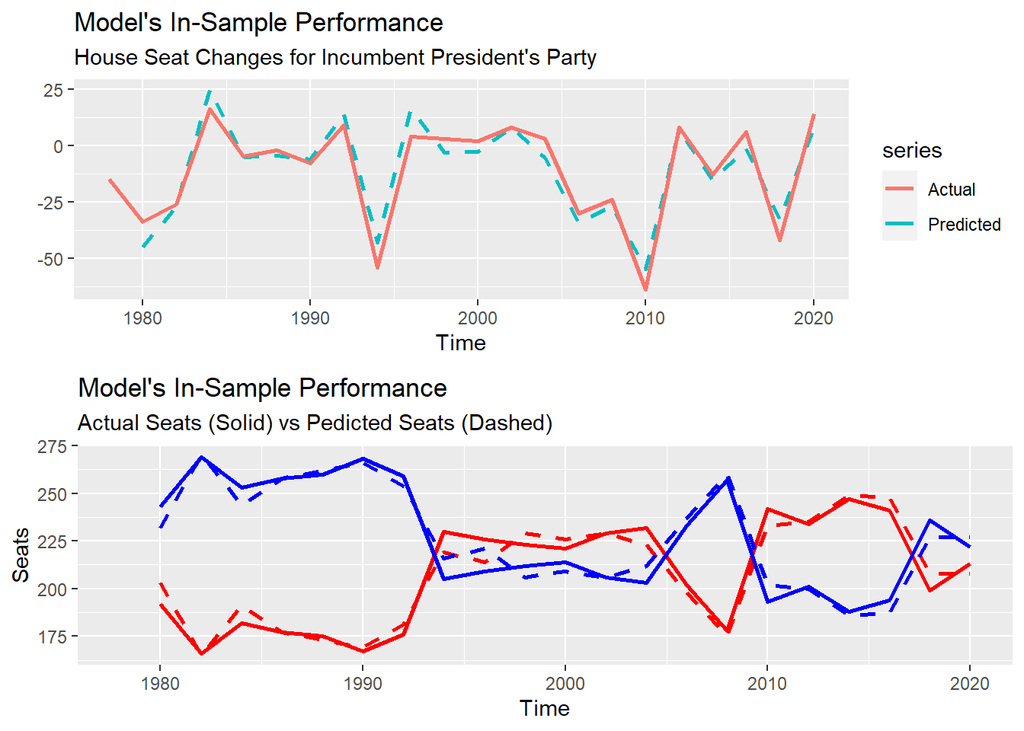

```r
plot1 <- autoplot(fitted(model2), series = "Predicted", lwd =1,lty = 2,) +
  autolayer(elec_ts[,12], series = "Actual", lwd =1) +
  labs( title = "Model's In-Sample Performance",
    subtitle = "House Seat Changes for Incumbent President's Party" ,
        y = "")

pred_DEM_seats <- NA
for (i in 1:(length(elec$GOP.Vote.Share)-1)) {

  if (elec$President[i+1] == 0){

    pred_DEM_seats<- c(pred_DEM_seats, elec$DEM.Seats[i] +
                                 round(model2$fitted.values[[i]],0))
  } else {

    pred_DEM_seats <- c(pred_DEM_seats, elec$DEM.Seats[i] -
                                 round(model2$fitted.values[[i]],0))
  }

}


pred_GOP_seats <- NA
for (i in 1:(length(elec$GOP.Vote.Share)-1)) {

  if (elec$President[i+1] == 1){

    pred_GOP_seats <- c(pred_GOP_seats, elec$GOP.Seats[i] +
                         round(model2$fitted.values[[i]],0))
  } else {

    pred_GOP_seats <- c(pred_GOP_seats, elec$GOP.Seats[i] -
                          round(model2$fitted.values[[i]],0))
  }

}
elec <- cbind(elec, pred_GOP_seats, pred_DEM_seats)

plot2 <- autoplot(ts( start = 1978, deltat = 2)) +
  autolayer(window(elec_ts[,4], start =1980), lwd =1,color = "Red") +
  autolayer(ts(pred_GOP_seats, start = 1978, deltat = 2), series = "Predicted GOP Seats", lty = 2, lwd = 1, color = "Red") +
  autolayer(window(elec_ts[,5], start =1980), lwd =1, color = "Blue") +
  autolayer(ts(pred_DEM_seats, start = 1978, deltat = 2), series = "Predicted DEM Seats", lty = 2, lwd = 1, color = "Blue") +
  labs( title = "Model's In-Sample Performance",
        subtitle = "Actual Seats (Solid) vs Pedicted Seats (Dashed)",
        y = "Seats")

grid.arrange(plot1, plot2)
```

## Did the Model correctly predict which party controls the House ?

```r
pred_pres_house_seats <- NA
for (i in 1:(length(elec$GOP.Vote.Share)-1)) {

  if (elec$President[i+1] == 0){

    pred_pres_house_seats <- c(pred_pres_house_seats, elec$DEM.Seats[i] +
                                 round(model2$fitted.values[[i]],0))
  } else {

    pred_pres_house_seats <- c(pred_pres_house_seats, elec$GOP.Seats[i] +
                                 round(model2$fitted.values[[i]],0))
  }

}
elec <- data.frame(elec,pred_pres_house_seats)

#Create column to show which party is predicted to control the House
pred_party_control <- NA
for (i in 1:(length(elec$GOP.Vote.Share)-1)) {

  if (elec$President[i+1] == 0 & elec$pred_pres_house_seats[i+1] >= 218 ){

    pred_party_control <- c(pred_party_control,"Predicted Democrat Control" )

  } else if (elec$President[i+1] == 0 & elec$pred_pres_house_seats[i+1] < 218) {

    pred_party_control <- c(pred_party_control, "Predicted Republican Control")

  } else if (elec$President[i+1] == 1 & elec$pred_pres_house_seats[i+1] >= 218) {

    pred_party_control <- c(pred_party_control, "Predicted Republican Control" )

  } else if (elec$President[i+1] == 1 & elec$pred_pres_house_seats[i+1] < 218) {

    pred_party_control <- c(pred_party_control, "Predicted Democrat Control" )
  }

}

elec <- data.frame(elec,pred_pres_house_seats,pred_party_control)
elec_house_control_test <- elec[6:length(elec$Control.of.House),] |>
  dplyr::select(Control.of.House, pred_party_control)


data.frame(Year = seq(1978,2020,2),
           Control_of_House = elec[,"Control.of.House"] ,
           Predicted_House_Control = elec[,"pred_party_control"]) |>
  filter(Year != 1978)
```

```
##    Year   Control_of_House      Predicted_House_Control
## 1  1980   Democrat Control   Predicted Democrat Control
## 2  1982   Democrat Control   Predicted Democrat Control
## 3  1984   Democrat Control   Predicted Democrat Control
## 4  1986   Democrat Control   Predicted Democrat Control
## 5  1988   Democrat Control   Predicted Democrat Control
## 6  1990   Democrat Control   Predicted Democrat Control
## 7  1992   Democrat Control   Predicted Democrat Control
## 8  1994 Republican Control Predicted Republican Control
## 9  1996 Republican Control   Predicted Democrat Control
## 10 1998 Republican Control Predicted Republican Control
## 11 2000 Republican Control Predicted Republican Control
## 12 2002 Republican Control Predicted Republican Control
## 13 2004 Republican Control Predicted Republican Control
## 14 2006   Democrat Control   Predicted Democrat Control
## 15 2008   Democrat Control   Predicted Democrat Control
## 16 2010 Republican Control Predicted Republican Control
## 17 2012 Republican Control Predicted Republican Control
## 18 2014 Republican Control Predicted Republican Control
## 19 2016 Republican Control Predicted Republican Control
## 20 2018   Democrat Control   Predicted Democrat Control
## 21 2020   Democrat Control   Predicted Democrat Control
```

```r
table(elec[,"pred_party_control"], elec[,"Control.of.House"])  # 20 out of last congressional Election
```

```
##
##                                Democrat Control Republican Control
##   Predicted Democrat Control                 11                  1
##   Predicted Republican Control                0                  9
```

### Comments:

In the last 21 Congressional elections, the model correctly predicted the control of the house 20 times. This represents an accuracy of 95.2%

The model wrongly predicted a Democratic Control in 1996 when President Clinton was running for re-election. The model was expecting 214 GOP Seats and 221 DEM Seats. However, the actual GOP-DEM seats are 226-209 and the error was 12 seats.

## 1-Step Forecast Cross Validation for Year 2016, 2018, 2020

```r
###########################################
##Out of Sample Testing. Outsample :2020 ##
###########################################

incum_party_change2 <- window(elec_ts[,12], start= 1980, end = 2018)
incum_running2 <- window(elec_ts[,10], start= 1980, end = 2018)
pres_party_seats2 <- window(elec_ts[,13], start = 1980, end = 2018)
ar_ts2 <- window(ts(ar, start = 1970, deltat = 2), start = 1980, end = 2018)
pres2 <- window(elec_ts[,"President"], start = 1980, end = 2018)

cs_adj_ts2 <- window(ts(cs_ts, start = c(1980), deltat = 2), end = 2018)


model_2020 <- tslm(incum_party_change2~cs_adj_ts2 + incum_running2 + I(pres_party_seats2^2) +ar_ts2 + pres2)

avgcs_2019_2020 <- cs |>
  filter(Year == 2020 )

exante_fc_out <- data.frame(cs_adj_ts2 = avgcs_2019_2020$consumer_sentiment,
                            incum_running2 = 1,
                            pres_party_seats2 = 199,
                            ar_ts2 = 0,
                            pres2 = 1)

fc_2020 <- forecast(model_2020, exante_fc_out)
error_2020 <- abs(round(fc_2020$mean[[1]],0) - 14)

#In 2020, the model would have expected a 8 seat gain for Incumbent President's party
#Actual Result is 14 seat gains.
#Error = 6 Seats

###########################################
##Out of Sample Testing. Outsample :2018 ##
###########################################

incum_party_change2018 <- window(elec_ts[,12], start= 1980, end = 2016)
incum_running2018 <- window(elec_ts[,10], start= 1980, end = 2016)
pres_party_seats2018 <- window(elec_ts[,13], start = 1980, end = 2016)
ar_ts2018 <- window(ts(ar, start = 1970, deltat = 2), start = 1980, end = 2016)
cs_adj_ts2018 <- window(ts(cs_ts, start = c(1980), deltat = 2), end = 2016)
pres2018 <- window(elec_ts[,"President"], start = 1980, end = 2016)

model_2018 <- tslm(incum_party_change2018~cs_adj_ts2018 + incum_running2018 +
                     I(pres_party_seats2018^2) + ar_ts2018 + pres2018)

avgcs_2017_2018 <- cs |>
  filter(Year == 2018 )

exante_fc_2018 <- data.frame(cs_adj_ts2018 = avgcs_2017_2018$consumer_sentiment,
                            incum_running2018 = 0,
                            pres_party_seats2018 = 241,
                            ar_ts2018 = 0,
                            pres2018 = 1)

fc_2018 <- forecast(model_2018, exante_fc_2018)
error_2018 <- abs(round(fc_2018$mean[[1]],0)- -42)

#In 2018, the model would have expected a  29 seat LOSS for Incumbent President's party
#Actual Result is 42 seat LOSS.
#Error  = 13 seats



###########################################
##Out of Sample Testing. Outsample :2016 ##
###########################################

incum_party_change2016 <- window(elec_ts[,12], start= 1980, end = 2014)
incum_running2016 <- window(elec_ts[,10], start= 1980, end = 2014)
pres_party_seats2016 <- window(elec_ts[,13], start = 1980, end = 2014)
ar_ts2016 <- window(ts(ar, start = 1970, deltat = 2), start = 1980, end = 2014)
cs_adj_ts2016 <- window(ts(cs_ts, start = c(1980), deltat = 2), end = 2014)
pres2016 <- window(elec_ts[,"President"], start = 1980, end = 2014)


model_2016 <- tslm(incum_party_change2016~cs_adj_ts2016 + incum_running2016 +
                     I(pres_party_seats2016^2) + ar_ts2016 + pres2016)

avgcs_2015_2016 <- cs |>
  filter(Year == 2016 )

exante_fc_2016 <- data.frame(cs_adj_ts2016 = avgcs_2015_2016$consumer_sentiment,
                             incum_running2016 = 0,
                             pres_party_seats2016 = 188,
                             ar_ts2016 = 0,
                             pres2016 =1 )

fc_2016 <- forecast(model_2016, exante_fc_2016)
error_2016 <- abs(round(fc_2016$mean[[1]],0)- 6)

#In 2016, the model would have expected a  8 seat LOSS for Incumbent President's party
#Actual Result is 6 seat GAIN.
#Error = 14 seats

avg_error <- round(mean(c(error_2016, error_2018, error_2020)),0)

errors <- data.frame(error_in_2020 = error_2020, error_in_2018 = error_2018, error_in_2016 = error_2016,
                     Average_error = avg_error)

errors
```

```
##   error_in_2020 error_in_2018 error_in_2016 Average_error
## 1             6            13            14            11
```

## Comments:

Using 1-period cross-validation, the model’s prediction error in 2016, 2018, and 2020 are 14,13, and 6 respectively.

The Model has a 1-period forecast cross-validation average error of 11 Seats.

# Forecast for 2022 Congressional House Election

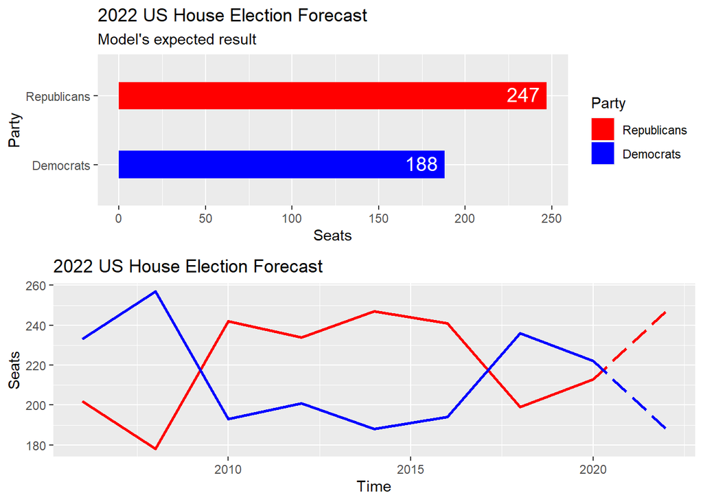

```r
avgcs_2021_2020 <- cs |>
  filter(Year == 2022)

exante_fc2 <- data.frame(cs_ts = avgcs_2021_2020$consumer_sentiment, incum_running = 0,
                        pres_party_seats = 222, ar_ts = 0 , pres = 0)


fc2 <-forecast(model2, exante_fc2 )

 if (exante_fc2$pres == 0){

      gop1 <- tail(elec$GOP.Seats,1) - round(fc2$mean[[1]],0)
      dem1 <- tail(elec$DEM.Seats,1) + round(fc2$mean[[1]],0)
    } else {

      gop1 <- tail(elec$GOP.Seats,1) + round(fc2$mean[[1]],0)
      dem1 <- tail(elec$DEM.Seats,1) - round(fc2$mean[[1]],0)
    }

fc2_seats <- data.frame( Party = c("Republicans", "Democrats") ,
                                Seats = c(gop1,dem1))

plot3 <- fc2_seats |>
  ggplot(aes(x = Party , y= Seats, fill = Party)) +
  geom_bar(stat = "identity", width = 0.4) +
  coord_flip() +
  geom_text(aes(label = Seats), vjust = 0.4,hjust = 1.2, size = 5, color = "white") +
  scale_fill_manual(values = c(Republicans = "Red", Democrats = "Blue")) +
  labs(title = "2022 US House Election Forecast",
       subtitle = "Model's expected result")

gop <- ts(c(tail(elec$GOP.Seats,1), tail(elec$GOP.Seats,1) - round(fc2$mean[[1]],0)), start = 2020, deltat = 2)
dem <- ts(c(tail(elec$DEM.Seats,1), tail(elec$DEM.Seats,1) + round(fc2$mean[[1]],0)), start = 2020, deltat = 2)


plot4 <- autoplot(ts( start = 2006, deltat = 2)) +
  autolayer(window(elec_ts[,4], start =2006), lwd =1,color = "Red") +
  autolayer(window(elec_ts[,5], start =2006), lwd =1, color = "Blue") +
  autolayer(gop, lwd =1, lty = 5, color = "Red") +
  autolayer(dem, lwd =1, lty = 5, color = "Blue")+
  labs( title = "2022 US House Election Forecast",
        y = "Seats")

grid.arrange(plot3, plot4)
```

## Comments:

The model expects the GOP to gain 34 Seats and DEM to lose 34 seats. Expected Result: GOP-DEM = 247-188.

The ex-ante forecasts are likely deterministic with >1 month to the election as the numbers for the variables are pretty much stable. As such, ex-ante forecasting does not pose a problem.

Given there is an average 1-period cross-validation error of 11 in the last 3 years,

We can expect the result to be

GOP = 247 +/- 11

DEM = 188 +/- 11

## CAVEATS:

Readers should take the model’s expectations with caution.

There are reasons to believe that the model is underestimating Democrat wins for 2022.

1. There was a historic supreme court rule on abortion.
2. There was redistricting that increased the number of democrat-leaning seats relative to republican-learning seats.

Both factors are important, but not captured in the model.

Nevertheless, the model does strongly suggest that the Republicans are heading into the midterms with a great advantage. Democrats are very likely to lose seats in this election cycle as midterm elections almost always swing against the incumbent President’s party. The poor economic environment, which is reflected in the consumer sentiment index, will aggravate seat losses for the Democrats in 2022.

Considering all factors, I strongly believe that the Republicans will recapture the House of Representatives in 2022.

Thank you for reading. You may contact me at gongchuen97@yahoo.com for questions or input.